# Homework#03_R10241209_Answer

Meng-Hsin, Wu

2022/3/5

## Data review

Let’s check the original datasets. First, it’s the dataset with density of fish and copepod at each station

```
##           Fish Copepod
## 1   137.323397 1119.00
## 2    20.967624 1153.00
## 3     0.000000 1719.00
## 4     0.000000  855.00
## 5   180.713557 1246.00
## 6    88.350447 2123.00
## 7   632.524771 1159.00
## 8    73.601882 1497.00
## 9  1021.901114 1351.00
## 10  555.772710  960.00
## 11  259.699980 2946.00
## 12  138.891900 1900.00
## 13  146.961237 1508.00
## 14  977.864100 4043.00
```

[output cut: 20 more lines]

## Question_1

Then let’s compute the mean and SE(mean) value of fish and copepod following normal theory.

```
## [1] "Mean density of fish: 322.451633316735"
```

```
## [1] "Mean density of copepod: 1972.37411764706"
```

```
## [1] "SE(mean) of fish: 61.2310707375046"
```

```
## [1] "SE(mean) of copepod: 342.554903173053"
```

## Question_1: Bootstrap

Now let’s compute the mean and SE(mean) of fish and copepod according to the bootstrap dataset.

```
## [1] "Bootstrap mean of fish density:  322.756638616987"
```

```
## [1] "Bootstrap mean of Copepod density:  1974.96059382353"
```

```
## [1] "Bootstrap SE(mean) of fish density:  57.538703473118"
```

```
## [1] "Bootstrap SE(mean) of copepod density:  330.706842133257"
```

## Question_1: Histogram of bootstrapped mean

Let’s check the distribution of our bootstrapped mean of fish and copepod.

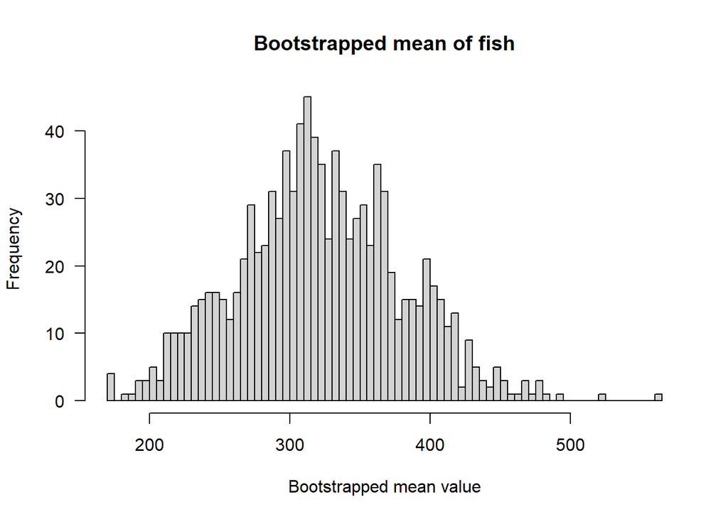

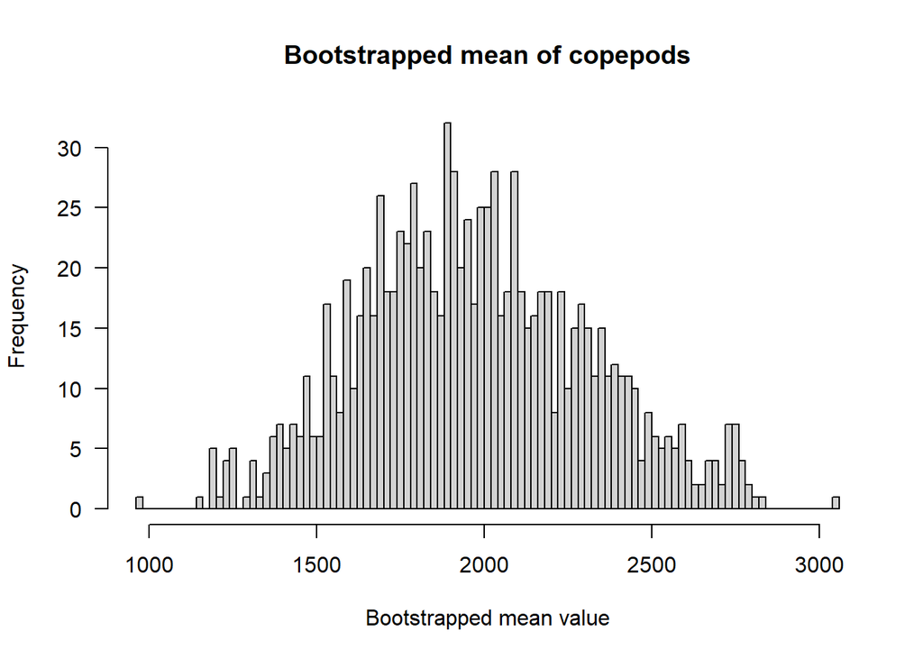

## Question_2

Now let’s use bootstrapping to compute median and SE(median) of fish and copepod density

```
## [1] "Median of fish density:  142.9265688"
```

```
## [1] "Median of Copepod density:  1352.5"
```

```
## [1] "Bootstrap median of fish density:  171.60835106613"
```

```
## [1] "Bootstrap median of Copepod density:  1385.23898"
```

```
## [1] "Bootstrap SE(median) of fish density:  93.7920599659745"
```

```
## [1] "Bootstrap SE(median) of Copepod density:  220.995004096234"
```

## Question_2: Histogram for bootstrapped medians

Let’s plot the distribution of bootstrapped median of fish and copepod density.

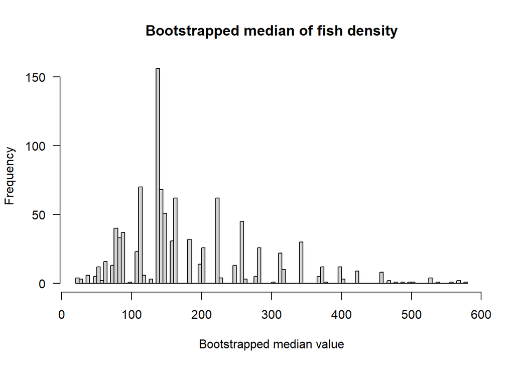

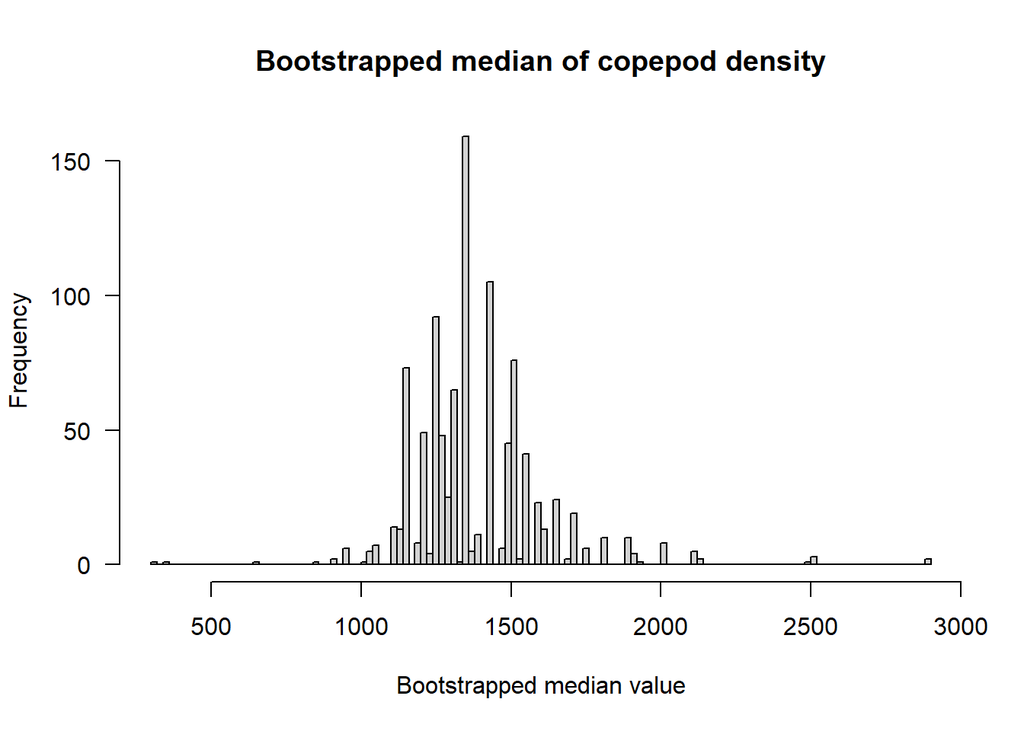

## Question_3

Plot the relationship between fish and copepod with regression line.

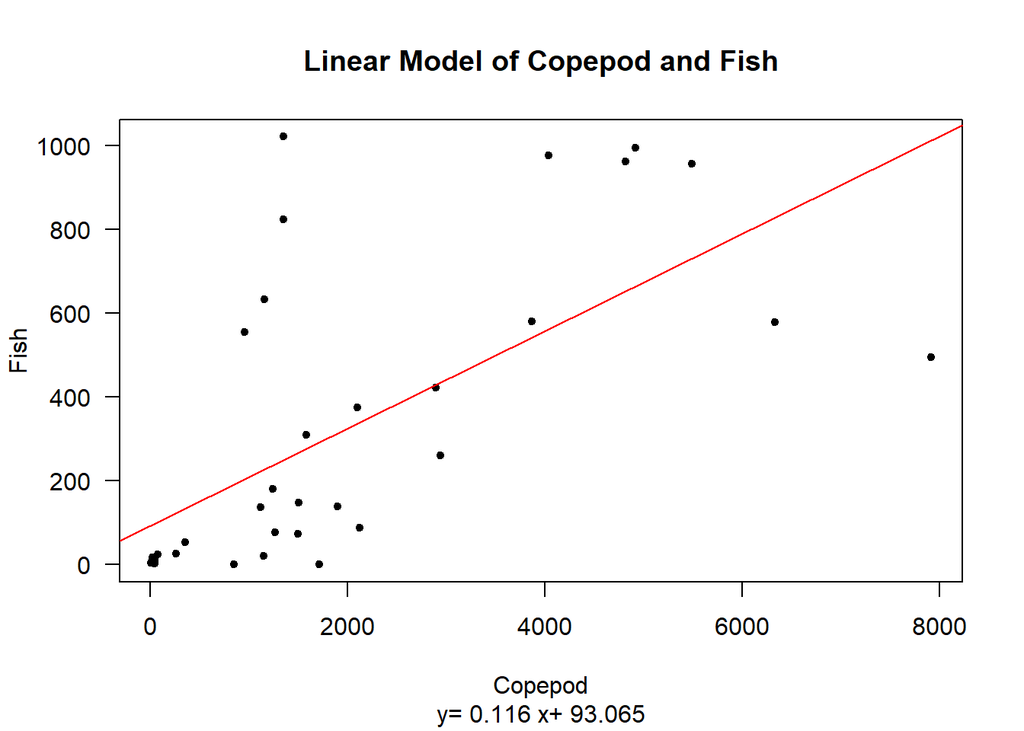

## Question_3: Coefficients

Compute beta_1 and beta_0 within the formula of the linear model.

```
## [1] "Correlation coefficient (beta_1): 0.116299932859911"
```

```
## [1] "Intercept (beta_0): 93.0646558597569"
```

## Question_3: Bootstrapped SE of coefficients

Let’s compute SE(beta_1) and SE(beta_0) from bootstrapped dataset respectively.

```
## [1] "SE(beta_1):  0.0318338567618904"
```

```
## [1] "SE(beta_0):  63.024347610509"
```

## Question_3: Histograms of bootstrapped coefficients

Let’s plot the distribution of the two coefficients from the bootstrapped dataset.

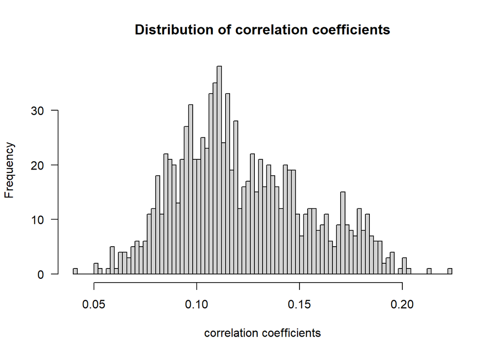

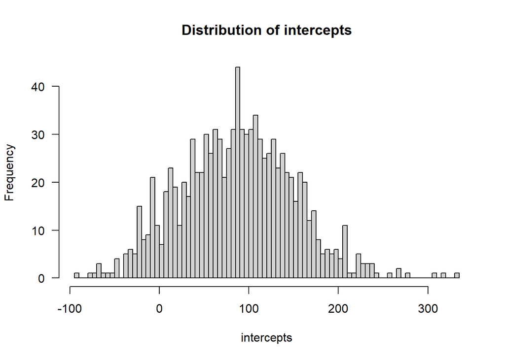

## Continued_1

Compute the mean and SE(mean) of fish and copepod density from jackknife dataset.

```
## [1] "Jackknife mean of fish density:  322.451633316735"
```

```
## [1] "Jackknife mean of copepod density:  1972.37411764706"
```

```
## [1] "Jackknife SE(mean) of fish density:  61.2310707375046"
```

```
## [1] "Jackknife SE(mean) of copepod density:  342.554903173053"
```

## Continued_1: Histogram for Jackknife

Try to plot the histogram of jackknife means of fish and copepod.

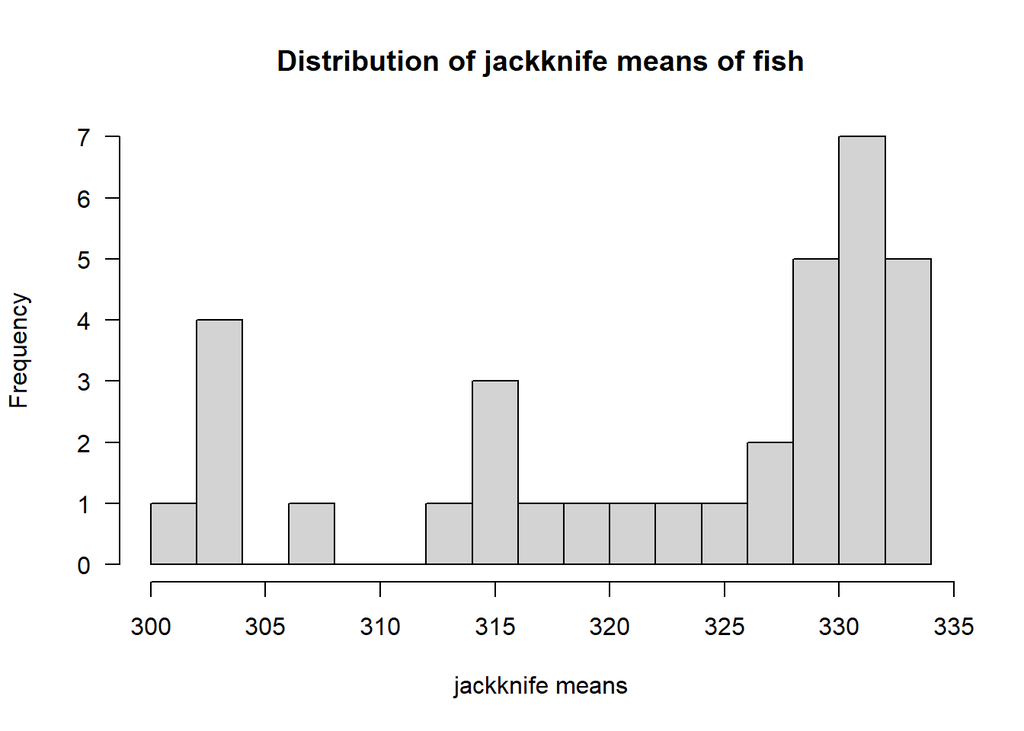

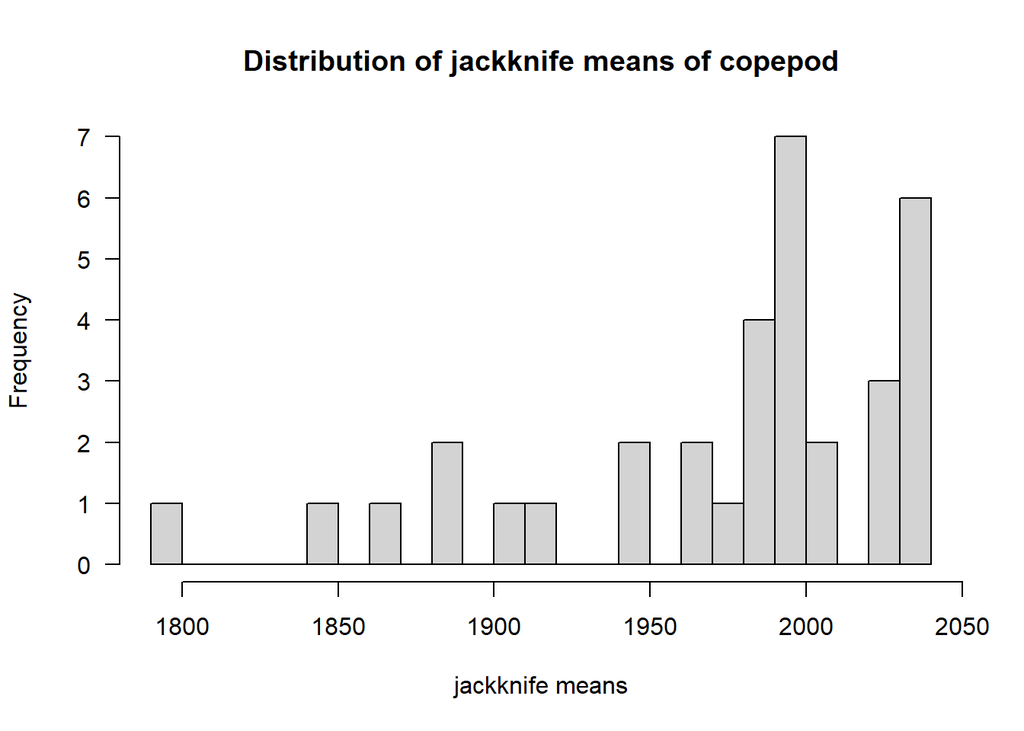

## Continued_2

The regression coefficients calculated from formula are as answers in Question_3. Let’s compute the SE(beta_1) and SE(beta_0) from jackknife datasets.

```
## [1] "Jackknife SE(correlation coefficient(beta_1)):  0.0380002961498038"
```

```
## [1] "Jackknife SE(Intercept(beta_0)):  69.2732921810956"
```

## Continued_2: Histogram of jackknife coefficients

Let’s plot the distribution of the two jackknife coefficients.

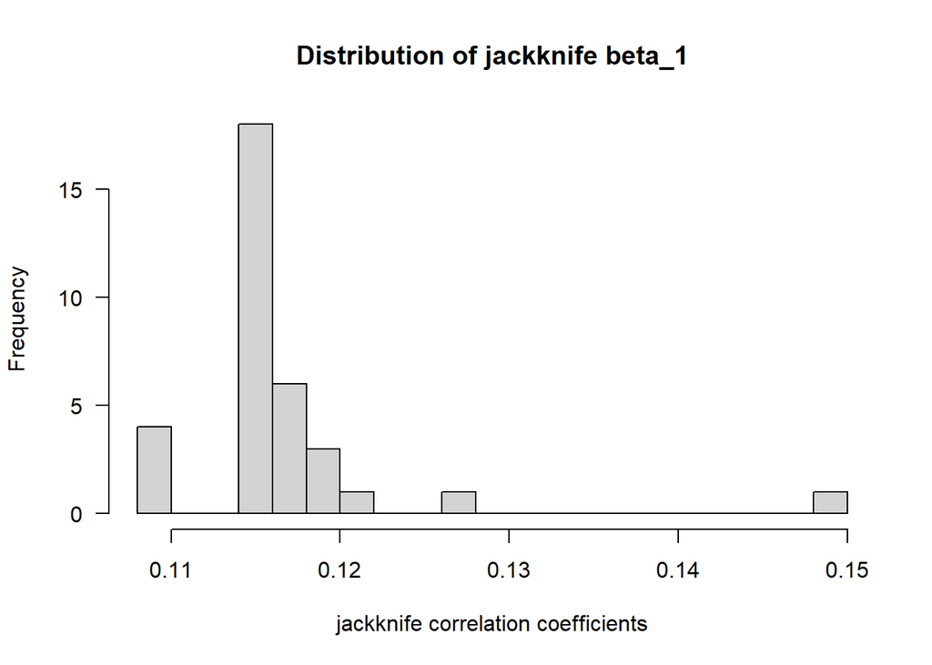

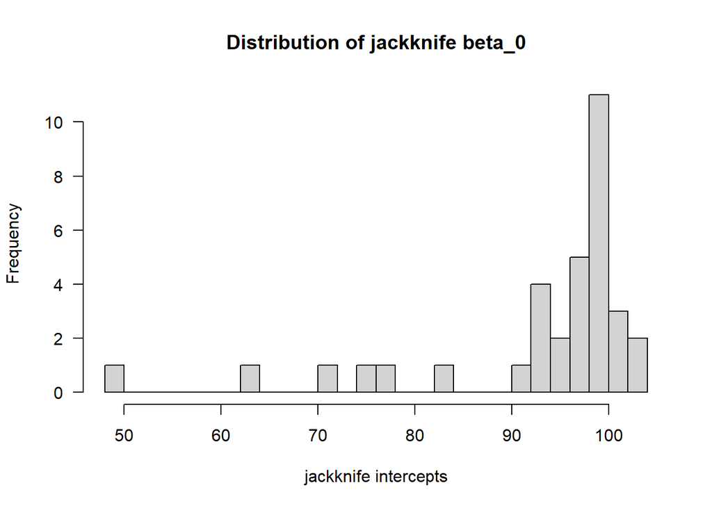

## Continued_3: Comparison

Compare the estimates from bootstrapping, jackknife and normal theory.

```
##                   mean   median  SE_mean SE_median
## Normal theory 322.4516 142.9266 61.23107        NA
## Bootstrapping 322.7566 171.6084 57.53870  93.79206
## Jackknife     322.4516       NA 61.23107        NA
```

```
##                   mean   median  SE_mean SE_median
## Normal theory 1972.374 1352.500 342.5549        NA
## Bootstrapping 1974.961 1385.239 330.7068   220.995
## Jackknife     1972.374       NA 342.5549        NA
```

```
##        coefficient SE_Bootstrapping SE_Jackknife
## beta 1   0.1162999       0.03183386    0.0380003
## beta 0  93.0646559      63.02434761   69.2732922
```